# R Notebook Réduction de dimensionnalité projet 1

Installation et chargement de FactoMineR

```r
#install.packages("FactoMineR")
library("FactoMineR")
```

Installation et chargement de factoextra pour visualisation

```r
library("devtools")
#install_github("kassambara/factoextra")
```

```r
library("factoextra")
```

```r
#install.packages("scatterplot3d") # Install
library("scatterplot3d") # load
```

```r
library (ggplot2)
```

```r
#install.packages("gtable")
library(gtable)
```

# 2.1 Projet 1 : Jeu de données Iris

## 0. Préparation des données

```r
#lecture du fichier iris jeu de données Data Analyst
irisDA <- read.csv("C:/Users/vgdb/Documents/DUDA/iris.csv", header=TRUE, sep = ",", dec = ".", fileEncoding = "latin1", check.names = FALSE)

#suppression de la colonne supplémentaire
irisDA <- subset (irisDA, select = -c(Id))

#conversion de la variable Species en factor
irisDA$Species <- as.factor(irisDA$Species)
head(irisDA)
```

|  | SepalLengthCm | SepalWidthCm | PetalLengthCm | PetalWidthCm | Species |
| --- | --- | --- | --- | --- | --- |
| 1 | 5.1 | 3.5 | 1.4 | 0.2 | Iris-setosa |
| 2 | 4.9 | 3.0 | 1.4 | 0.2 | Iris-setosa |
| 3 | 4.7 | 3.2 | 1.3 | 0.2 | Iris-setosa |
| 4 | 4.6 | 3.1 | 1.5 | 0.2 | Iris-setosa |
| 5 | 5.0 | 3.6 | 1.4 | 0.2 | Iris-setosa |
| 6 | 5.4 | 3.9 | 1.7 | 0.4 | Iris-setosa |

```r
irisDA.active <- irisDA[,1:4]
summary (irisDA.active)
```

```
 SepalLengthCm    SepalWidthCm   PetalLengthCm    PetalWidthCm
 Min.   :4.300   Min.   :2.000   Min.   :1.000   Min.   :0.100
 1st Qu.:5.100   1st Qu.:2.800   1st Qu.:1.600   1st Qu.:0.300
 Median :5.800   Median :3.000   Median :4.350   Median :1.300
 Mean   :5.843   Mean   :3.054   Mean   :3.759   Mean   :1.199
 3rd Qu.:6.400   3rd Qu.:3.300   3rd Qu.:5.100   3rd Qu.:1.800
 Max.   :7.900   Max.   :4.400   Max.   :6.900   Max.   :2.500
```

```r
irisDA.active %>% summarise_each(funs(sd))
```

| SepalLengthCm | SepalWidthCm | PetalLengthCm | PetalWidthCm |
| --- | --- | --- | --- |
| 0.8280661 | 0.4335943 | 1.76442 | 0.7631607 |

## 1. Chargez dans votre environnement le jeu de données IRIS, et représentez en trois dimensions (comme dans la Figure 1) les individus sur les axes suivants : Sepal.Length, Petal.Length, et Sepal.Width

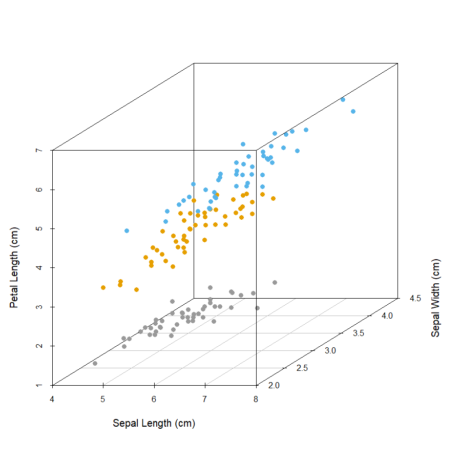

```r
# affecte une couleur à chaque espece
colors <- c("#999999", "#E69F00", "#56B4E9")
colors <- colors[as.numeric(irisDA$Species)]

# représentation 3D des 3 premières variables
scatterplot3d(irisDA[,1:3],
              xlab = "Sepal Length (cm)",
              ylab = "Sepal Width (cm)",
              zlab = "Petal Length (cm)", pch = 16, color=colors)
```

## 2. Répétez l’étape précédente, mais aprés avoir centré puis réduit les variables correspondantes

```r
library(dplyr)

#Centrer et réduire les variables
irisDACR <- irisDA %>% mutate_at(c('SepalLengthCm', 'SepalWidthCm','PetalLengthCm', 'PetalWidthCm'), ~(scale(.) %>% as.vector))
#irisDACR
```

```r
irisDACR.active <- as.data.frame(irisDACR[,1:4])
summary (irisDACR.active)
```

```
 SepalLengthCm       SepalWidthCm     PetalLengthCm      PetalWidthCm
 Min.   :-1.86378   Min.   :-2.4308   Min.   :-1.5635   Min.   :-1.4396
 1st Qu.:-0.89767   1st Qu.:-0.5858   1st Qu.:-1.2234   1st Qu.:-1.1776
 Median :-0.05233   Median :-0.1245   Median : 0.3351   Median : 0.1328
 Mean   : 0.00000   Mean   : 0.0000   Mean   : 0.0000   Mean   : 0.0000
 3rd Qu.: 0.67225   3rd Qu.: 0.5674   3rd Qu.: 0.7602   3rd Qu.: 0.7880
 Max.   : 2.48370   Max.   : 3.1043   Max.   : 1.7804   Max.   : 1.7052
```

```r
irisDACR.active %>% summarise_each(funs(sd))
```

| SepalLengthCm | SepalWidthCm | PetalLengthCm | PetalWidthCm |
| --- | --- | --- | --- |
| 1 | 1 | 1 | 1 |

Moyenne = 0 et écart type = 1 pour les variables centrées et réduites

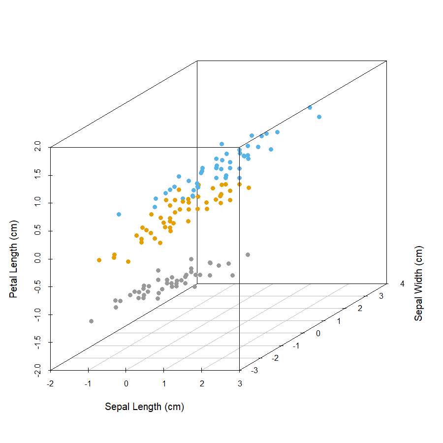

```r
# affecte une couleur à chaque espece
colors <- c("#999999", "#E69F00", "#56B4E9")
colors <- colors[as.numeric(irisDA$Species)]

# représentation 3D des 3 premières variables
scatterplot3d(irisDACR[,1:3],
              xlab = "Sepal Length (cm)",
              ylab = "Sepal Width (cm)",
              zlab = "Petal Length (cm)", pch = 16, color=colors)
```

## 3. Réalisez une analyse en composantes principales, puis affichez les individus sur les deux premières composantes. Vous choisirez des couleurs différentes selon le type d’espèce d’iris considéré, comme en Figure 2. Vous réaliserez cette étape en deux fois : une première fois sans standardisation des données, une seconde fois avec. A partir de maintenant, vous travaillerez toujours avec les variables centrées réduites

3.a ACP des variables réelles

```r
library("FactoMineR")
res.pca <- PCA(irisDA, quali.sup=c(5),scale.unit=FALSE, graph=FALSE)
print(res.pca)
```

```
**Results for the Principal Component Analysis (PCA)**
The analysis was performed on 150 individuals, described by 5 variables
*The results are available in the following objects:

   name                description
1  "$eig"              "eigenvalues"
2  "$var"              "results for the variables"
3  "$var$coord"        "coord. for the variables"
4  "$var$cor"          "correlations variables - dimensions"
5  "$var$cos2"         "cos2 for the variables"
6  "$var$contrib"      "contributions of the variables"
7  "$ind"              "results for the individuals"
8  "$ind$coord"        "coord. for the individuals"
9  "$ind$cos2"         "cos2 for the individuals"
10 "$ind$contrib"      "contributions of the individuals"
11 "$quali.sup"        "results for the supplementary categorical variables"
12 "$quali.sup$coord"  "coord. for the supplementary categories"
13 "$quali.sup$v.test" "v-test of the supplementary categories"
14 "$call"             "summary statistics"
15 "$call$centre"      "mean of the variables"
16 "$call$ecart.type"  "standard error of the variables"
17 "$call$row.w"       "weights for the individuals"
18 "$call$col.w"       "weights for the variables"
```

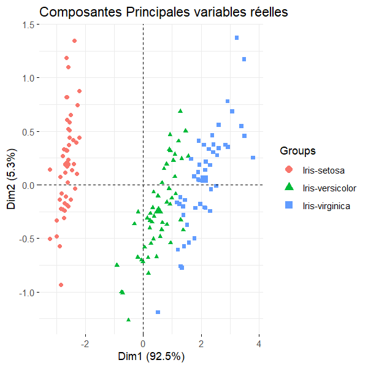

```r
# Représentation des individus
fviz_pca_ind(res.pca,  label="none", habillage=irisDA$Species,
             title="Composantes Principales variables réelles")
```

3.b ACP des variables centrées et réduites

```r
library("FactoMineR")
res.pcacr <- PCA(irisDACR, quali.sup=c(5),scale.unit=FALSE, graph=FALSE)
#print(res.pcacr)
```

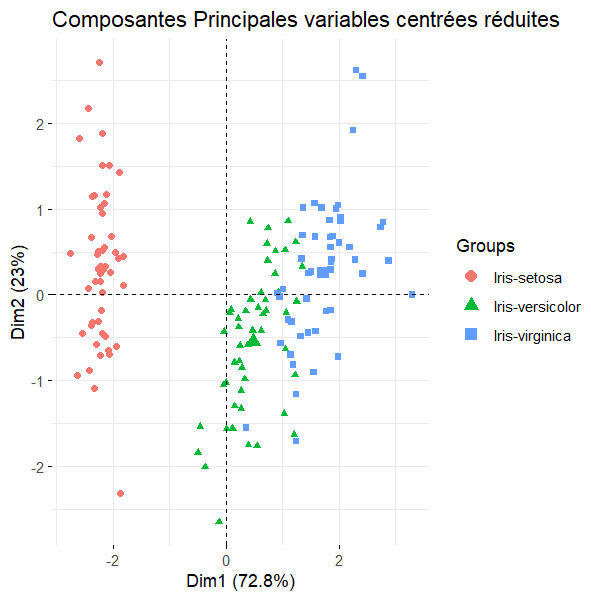

```r
# Représentation des individus
fviz_pca_ind(res.pcacr,  label="none", habillage=irisDACR$Species,
             title="Composantes Principales variables centrées réduites")
```

```r
#plot.PCA(res.pcacr,invisible=c('quali','ind.sup'),title="Analyse des Composantes Principales variables centrées réduites",label ='none',habillage='Species',col.quali.sup='#FF00FF')
```

La standardisations des variables (centrées et réduites) permet de diminuer la part de la variance exprimée sur la principale composante 1 (92,5% -> 72,8%) et d’augmenter la part de la variance exprimée sur la prinicpale composante 2 (5,3% à 23%)

## 4. Calculez deux à deux les corrélations entre les différentes variables du jeu de données (en anglais : pairwise correlations). Représentez ces corrélations sous la forme d’un corrélogramme de votre choix (par ex., avec des bulles et des couleurs).

```r
# matrice des corrélations
cor.mat <- round(cor(irisDACR.active),2)
cor.mat
```

```
              SepalLengthCm SepalWidthCm PetalLengthCm PetalWidthCm
SepalLengthCm          1.00        -0.11          0.87         0.82
SepalWidthCm          -0.11         1.00         -0.42        -0.36
PetalLengthCm          0.87        -0.42          1.00         0.96
PetalWidthCm           0.82        -0.36          0.96         1.00
```

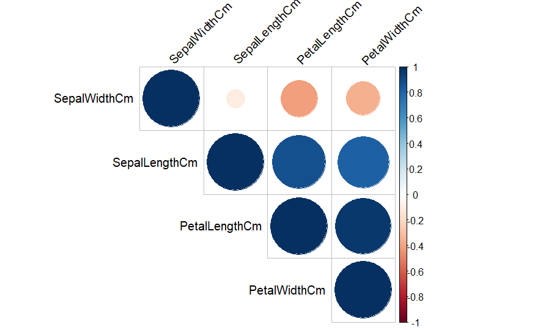

```r
#install.packages("corrplot")
# corrélogramme
library("corrplot")
corrplot(cor.mat, type="upper", order="hclust",
         tl.col="black", tl.srt=45)
```

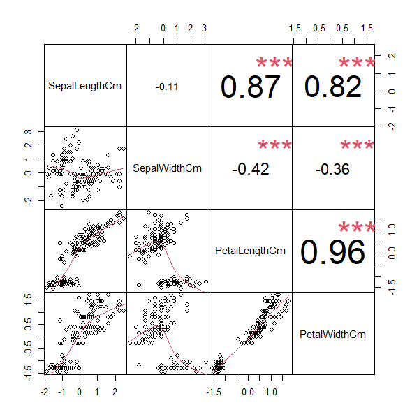

```r
#install.packages("PerformanceAnalytics")
# matrice avec courbe et coefficients de corrélation.
library("PerformanceAnalytics")
chart.Correlation(irisDACR[1:4], histogram=FALSE, pch=21)
```

```r
irisDACR
```

|  | SepalLengthCm | SepalWidthCm | PetalLengthCm | PetalWidthCm | Species |
| --- | --- | --- | --- | --- | --- |
| 1 | -0.89767388 | 1.0286113 | -1.33679402 | -1.30859282 | Iris-setosa |
| 2 | -1.13920048 | -0.1245404 | -1.33679402 | -1.30859282 | Iris-setosa |
| 3 | -1.38072709 | 0.3367203 | -1.39346985 | -1.30859282 | Iris-setosa |
| 4 | -1.50149039 | 0.1060900 | -1.28011819 | -1.30859282 | Iris-setosa |
| 5 | -1.01843718 | 1.2592416 | -1.33679402 | -1.30859282 | Iris-setosa |
| 6 | -0.53538397 | 1.9511326 | -1.16676652 | -1.04652483 | Iris-setosa |
| 7 | -1.50149039 | 0.7979809 | -1.33679402 | -1.17755883 | Iris-setosa |
| 8 | -1.01843718 | 0.7979809 | -1.28011819 | -1.30859282 | Iris-setosa |
| 9 | -1.74301699 | -0.3551707 | -1.33679402 | -1.30859282 | Iris-setosa |
| 10 | -1.13920048 | 0.1060900 | -1.28011819 | -1.43962681 | Iris-setosa |

[output cut: 140 more lines]

```r
#install.packages("gclus")
library(gclus)
```

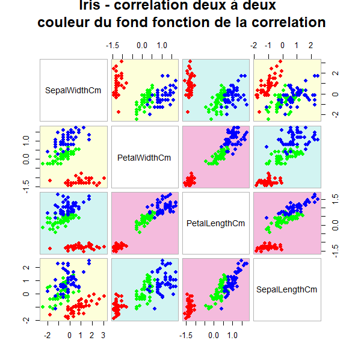

```r
corr <- abs(cor(irisDACR[1:4]))

colors <- dmat.color(corr)
order <- order.single(corr)

cpairs (irisDACR[1:4],
        order,
 #      labels = colnames (irisDACR[1:4]),
       panel.colors = colors,
       pch = 21,
       border.color = "grey70",
       bg = rainbow(3)[irisDACR$Species],
       col = rainbow(3)[irisDACR$Species],
       main = "Iris - correlation deux à deux \n couleur du fond fonction de la correlation",
       row1attop = TRUE,
       gap = 0.45,
       cex.labels = NULL,
       font.labels = 1)
```

Les variables les plus corrélées sont la longueur du pétale et la largeur du pédale.

## 5. Représentez maintenant avec Iris un cercle des corrélations, comme en Figure 3. Quelles sont les variables qui semblent les plus corrélées, d’après ce que vous avez obtenu à l’étape précédente, et comment cette forte corrélation se matérialise-t-elle dans le cercle des corrélations ?

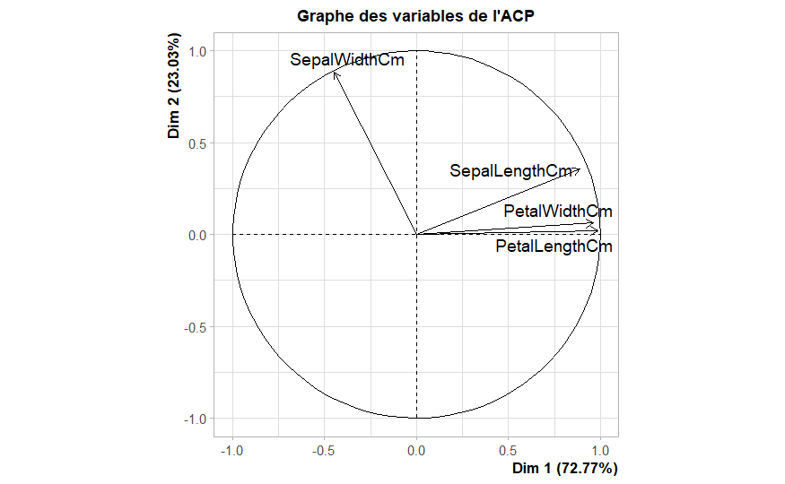

```r
plot.PCA(res.pcacr,choix='var',title="Graphe des variables de l'ACP")
```

La longueur et la largeur des pétales sont les variables les plus corrélées avec un coefficient proche de 1 (= 0,96). La correlation est également visible dans la courbe car les points se répartissent globalement dans une diagonale allant du coin en bas à gauche jusqu’au point en haut à droite ce qui est le signe d’une corrélation linéaire. Dans le cercle de corrélation les deux variables ont la même direction.

## 6. Représentez cette fois le biplot, comme en Figure 4, avec à la fois les variables, et les individus. Quelle part de la variance est-elle représentée sur le plan représenté ?

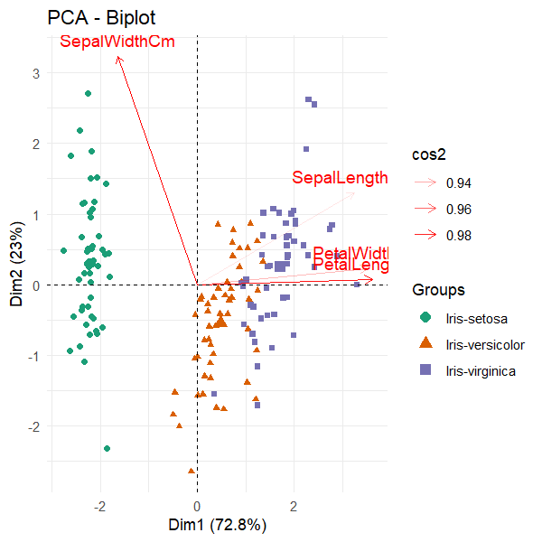

```r
fviz_pca_biplot(res.pcacr,
  habillage = irisDACR$Species, addEllipses = FALSE,
  col.var = "red", alpha.var ="cos2",
  label = "var") +
  scale_color_brewer(palette="Dark2")+
  theme_minimal()
```

La part de variance représentée est de 95,8% (72,8% pour la composante principale 1 + 23% pour la composante principale 2).

## 7. Comme dans la Figure 5, effectuez le test des bâtons brisés à travers un ”scree plot”, afin de déterminer combien de dimensions il vous paraît le plus pertinent de retenir

```r
# Pourcentage de la variance des composantes principales
eigenvalues <- res.pcacr$eig
#eigenvalues
```

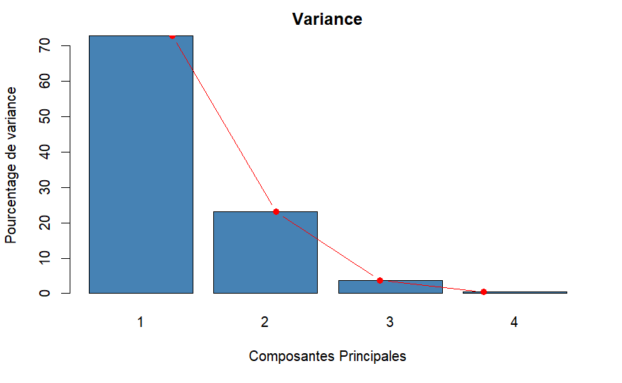

```r
barplot(eigenvalues[, 2], names.arg=1:nrow(eigenvalues),
       main = "Variance",
       xlab = "Composantes Principales",
       ylab = "Pourcentage de variance",
       col ="steelblue")
# Add connected line segments to the plot
lines(x = 1:nrow(eigenvalues), eigenvalues[, 2],
      type="b", pch=19, col = "red")
```

La première dimension exprime déjà 72,8%. Ce qui est suffisant. Faire une analyse sur une seule dimension est toutefois limité. Les deux premières composantes principales représentent 95,8%. Dans la ligne du pourcentage de variance un coude est observé à la deuxième composante principale. Ainsi il parait pertinent de garder les deux premières composantes (ou dimensions).

## 8. Rajoutez sur la figure précédente une courbe permettant de déterminer la part de variance expliquée au fil des variables

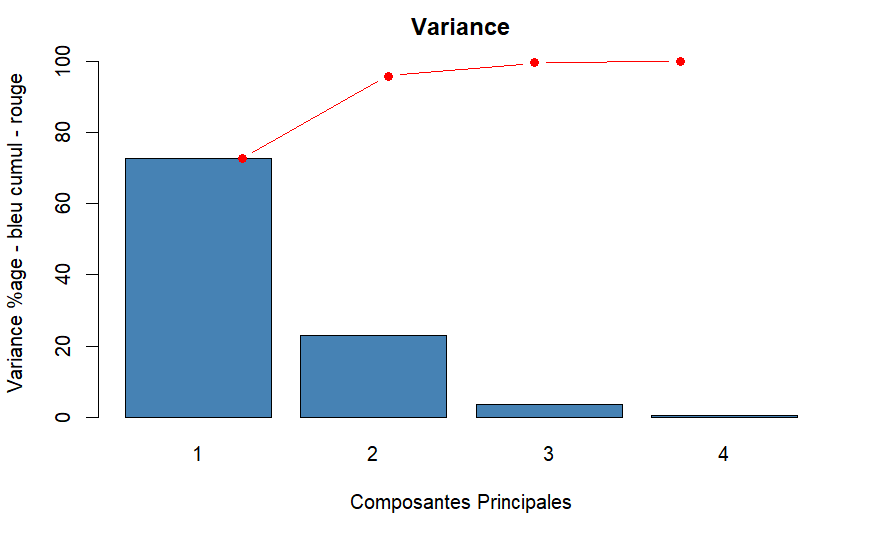

```r
barplot(eigenvalues[, 2], names.arg=1:nrow(eigenvalues),
       main = "Variance",
       xlab = "Composantes Principales",
       ylab = "Variance %age - bleu cumul - rouge",
       col ="steelblue", ylim=c(0,103))
# Add la part de variance cumulée
lines(x = 1:nrow(eigenvalues), cumsum(eigenvalues[, 2]),
      type="b", pch=19, col = "red", ylim=c(0,103))
```

## 9. Produisez une table représentant pour chaque composantes les eigenvalues et le % de variance expliquée, comme dans la Table 1 ci-dessous. Quel lien semble unir les eigenvalues et le % de variance expliquée ?

```r
eigenvalues
```

```
       eigenvalue percentage of variance cumulative percentage of variance
comp 1 2.89141263             72.7704521                          72.77045
comp 2 0.91507946             23.0305233                          95.80098
comp 3 0.14637092              3.6838320                          99.48481
comp 4 0.02047032              0.5151927                         100.00000
```

Les eigenvalues sont la somme des carrés des distances entre les points et la dimension. Ils sont donc fortement liés à la variance. Les eigenvalues augmentent en même temps que le pourcentage de la variance expliquée.

## 10. Représentez maintenant à travers une table la saturation (factor loading) les différentes variables sur les composantes principales. Quel est pour la CP1, la variable qui présente la saturation la plus forte ? Quel lien pouvez-vous effectuer avec le cercle des corrélations vu précédemment ?

```r
# calcul des saturations des différentes variables sur les différents axes
saturation <- sweep(res.pcacr$var$coord,2,sqrt(res.pcacr$eig[1:ncol(res.pcacr$var$coord),1]),FUN="/")
saturation
```

```
                   Dim.1      Dim.2      Dim.3      Dim.4
SepalLengthCm  0.5223716 0.37231836 -0.7210168 -0.2619956
SepalWidthCm  -0.2633549 0.92555649  0.2420329  0.1241348
PetalLengthCm  0.5812540 0.02109478  0.1408923  0.8011543
PetalWidthCm   0.5656110 0.06541577  0.6338014 -0.5235463
```

On note, sur la composante principale 1, la plus forte saturation (0,58) pour la variable longueur des pétales. Cette saturation s’observe sur le cercke des corrélations par l’angle le plus faible entre la variable longueur des pétales et la dimension1 (ou composante princiaple)

## 11. Réalisez une table où pour chaque CP, en ligne, vous représentez la variable dont la saturation est la plus forte pour une CP donnée. Il existe une commande dédiée en Python

```r
# on repère la discipline avec la saturation la plus importante pour chaque axe
ligne <- NULL
colname <- NULL
for (i in 1:ncol(saturation)) {
  ligne <- append(ligne,names(which.max(saturation[,i])))
}
tab <- ligne


#names (tab) <- paste0("ModalitéDim_", 1:ncol(saturation))
names (tab) <- colnames(saturation)
tab
```

```
          Dim.1           Dim.2           Dim.3           Dim.4
"PetalLengthCm"  "SepalWidthCm"  "PetalWidthCm" "PetalLengthCm"
```

## 12. Reprenez maintenant le cercle des corrélations fait précédemment. Quel lien effectuez-vous entre saturation des variables et l’orientation des flèches représentant des vecteurs pour chaque variable ?

Pour chaque dimension, la saturation peut être partagée. C’est le cas pour la dimension 1 où trois variables (longueur des pétales, largeur des pétales et longueur des sépales) ont une saturation forte, respectivement (0,58, 0,56 et 0,52). Les vecteurs de ces trois variables forment un angle très petit avec la dimension 1. Par dimension, plus l’angle est petit plus la saturation est forte. Pour la dimension 2, la saturation des variables est plus exclusivement portée par la variable largeur des sépales. L’angle formé entre le vecteur de cette variable et la dimension2 est également petit.

## 13. Expliquez ce que signifie, au juste, la qualité de la représentation d’une variable par une ACP. Représentez maintenant le cercle des corrélations, mais de la couleur de la flèche doit dépendre la qualit´e de la représentation des variables par l’ACP. Vous utiliserez les cos2, puis les contributions. Quelle est la principale différence entre ces deux métriques ?

La représentation d’une variable est de qualité lorsque son vecteur est proche du cercle. Ces éléments ont une forte coordonnée, sont bien projetés et peuvent être interprétés. Le cosinus carré entre le vecteur et la dimension est proche de 1.

13.a cos2

```r
?fviz_pca_var
```

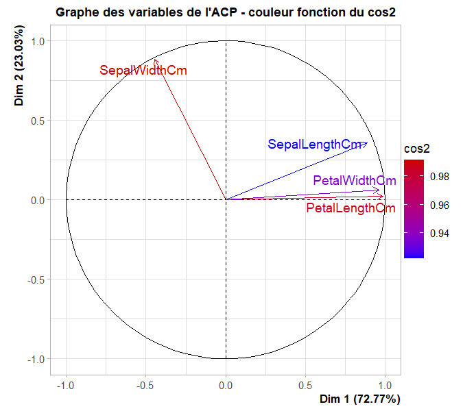

```r
plot.PCA(res.pcacr,choix='var',habillage = 'cos2',select='cos2  0',unselect=0,title="Graphe des variables de l'ACP - couleur fonction du cos2")
```

```r
#fviz_pca_var(res.pcacr, col.var="cos2", xlim=c(-1,1.2), ylim=c(-1,1), circle = TRUE, title = "Variables de l'ACP - couleur fonction du cos2")
```

13.b contribution

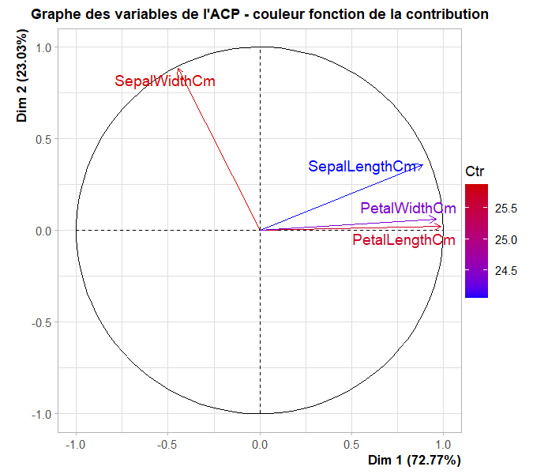

```r
#fviz_pca_var(res.pcacr, col.var="contrib", xlim=c(-1,1.2), ylim=c(-1,1), Title = "Variables de l'ACP - couleur fonction de la contribution")
plot.PCA(res.pcacr,choix='var',habillage = 'contrib',select='contrib  4',unselect=0,title="Graphe des variables de l'ACP - couleur fonction de la contribution")
```

```r
#plot.PCA(res.PCA,choix='var',habillage = 'contrib',select='contrib  4',unselect=0,title="Graphe des variables de l'ACP")
```

Le cosinus carré est proche de un tandis que la contribution est autour de 25.

## 14. Répétez l’étape précédentes, mais en représentant cette fois uniquement les individus sur le plan factoriel. De la même manière, la couleur des individus devra dépendre de la qualité de leur représentation par l’ACP

14.a cos2

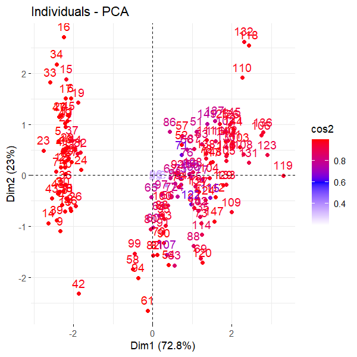

```r
fviz_pca_ind(res.pcacr, col.ind="cos2") +
      scale_color_gradient2(low="white", mid="blue",
      high="red", midpoint=0.6, space = "Lab")
```

14.b contribution

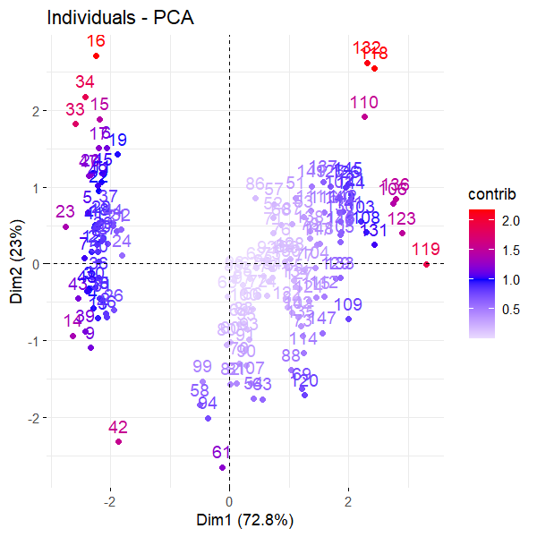

```r
fviz_pca_ind(res.pcacr, col.ind="contrib") +
      scale_color_gradient2(low="white", mid="blue",
      high="red", midpoint=1, space = "Lab")
```

## 15. Produisez une table représentant la contribution des individus aux deux premiers axes de l’ACP. Que représente au juste cette contribution ?

```r
IndContriPC12 <- res.pcacr$ind$contrib[,1:2]
head(IndContriPC12)
```

```
      Dim.1      Dim.2
1 1.1745035 0.18507065
2 0.9970098 0.31085946
3 1.2842184 0.07340099
4 1.2159983 0.23957192
5 1.3069082 0.32949826
6 0.9818827 1.66879240
```

La contribution des individus est maximisée lorsqu’ils se situent vers l’extérieur. Ils ont une bonne projection sur une des dimensions voire sur les deux dimensions lorque l’individu est éloigné des deux axes.

## 16. Représentez maintenant les individus sur le plan factoriel, mais rajoutez des ellipses. Expliquez en quoi ces ellipses se distinguent d’une classification par un algorithme de type kmeans par exemple.

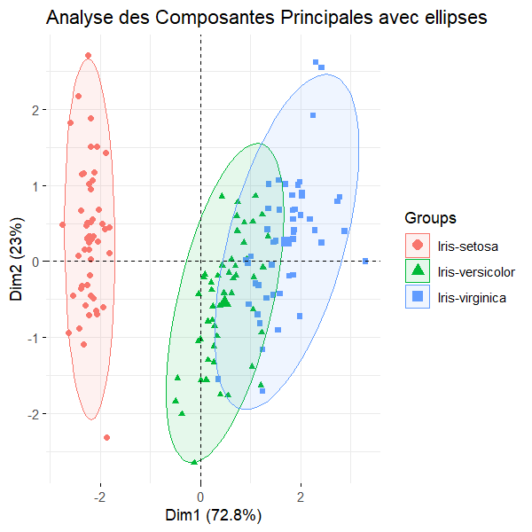

```r
# Représentation des individus avec des ellipses
fviz_pca_ind(res.pcacr,  label="none", habillage=irisDACR$Species, addEllipses = TRUE, ellipse.level=0.95, title="Analyse des Composantes Principales avec ellipses")
```

Les ellipses sont un regroupement visuel des individus en fonction de leur place sur la figure. Les individus ne sont pas classés. A l’inverse, l’algorithme k-means opère une classification des individus.

## 17. Réaliser un biplot en considérant la longueur des pétales comme une variable supplémentaire (elle devra apparaître en bleu). Quels sont les principaux changements constatés dans le graphique créé ?

```r
# PCA avec longueur des pétales comme variable qualitative
res.pcacrsup <- PCA(irisDACR,quanti.sup="PetalLengthCm", quali.sup=5, graph = FALSE)
```

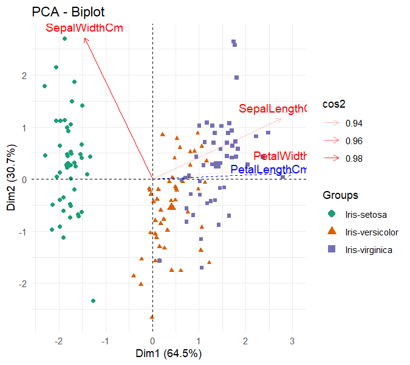

```r
fviz_pca_biplot(res.pcacrsup,
  habillage = irisDACR$Species, addEllipses = FALSE,
  col.var = "red", alpha.var ="cos2",
  label = "var") +
  scale_color_brewer(palette="Dark2")+
  theme_minimal()
```

On observe une diminution du pourcentage de variance exprimée sur les deux dimensions lorsqu’on neutralise la variable ayant la plus forte contribution.

## 18. Rappelez le fonctionnement de l’algorithme k-means, insister sur la différence entre l’étape d’expectation et l’étape de maximisation. Décrivez la trajectoire que suit les différents centroïdes au fil des itérations

L’algorithme k-means vise à diviser des points (individus) en k groupes, appelés clusters, homogènes et compacts. Il minimise le total des carrés des distances des points à leur centroïde (intra-cluster) et se déroule en plusieurs étapes.

1. Les points sont affectés à un centroïde de façon aléatoire.
2. Les centroïdes sont placés au milieu de leur nuage de points (centre de gravité).
3. Chaque point est affecté au centroïde le plus proche. Les étapes 2 et 3 sont répétées jusqu’à ce que les centroïdes ne bougent plus.

Les centroïdes convergent vers le centre du cluster de points. Leur déplacement est de plus en plus petit au fil des itérations.

L’algorithme k-means a été utilisé la première fois par James MacQueen en 1967.

L’algorithme de clustering EM (Expectation-Maximisation) est un algorithme itératif en deux étapes : l’expectation (E) où l’on calcule l’espérance de la vraisemblance et la maximisation (M) où l’on estime le maximum de vraisemblance trouvée à l’étape E. Cet algorithme est proposé par Dempster et al. en 1977.

## 19. Appliquez l’algorithme kmeans pour réaliser un clustering des différentes fleurs recensées. Puis afficher dans le même plan que celui de l’ACP les différents individus avec une couleur par cluster. Prendre donc en entrée un nombre défini de composantes principales, et non les variables originelles. Commencez avec k=3. Décrivez les caractéristiques de ces trois clusters, en termes de moyennes de variables quantitatives, et de proportion des différentes espèces représentées.

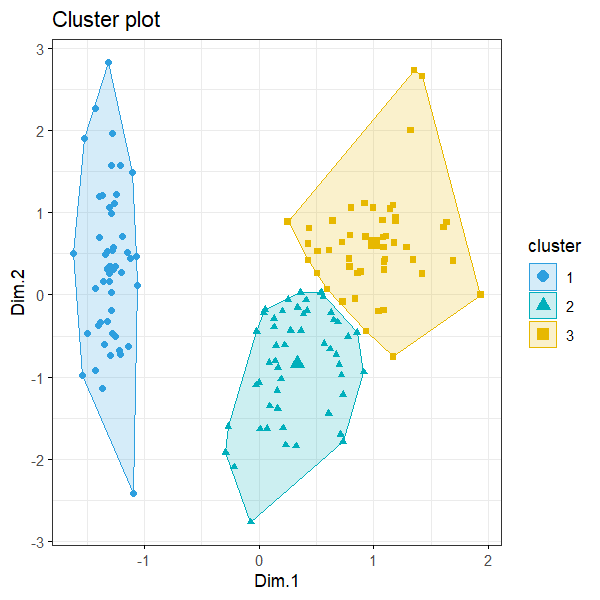

```r
#res.pcacr$ind$coord[,1:2]
res.kmcrpc12 <- kmeans(res.pcacr$ind$coord[,1:2], centers = 3, nstart = 20)
res.kmpc12 <- kmeans(res.pca$ind$coord[,1:2], centers = 3, nstart = 20)

fviz_cluster(res.kmcrpc12, data = res.pcacr$ind$coord[,1:2],
             palette = c("#2E9FDF", "#00AFBB", "#E7B800"),
             geom = "point",
             ellipse.type = "convex",
             ggtheme = theme_bw()
             )
```

```r
#res.kmcrpc12
```

```r
# comparaison des espèces et des 3 clusters
table (res.kmcrpc12$cluster,irisDA$Species)
```

```
    Iris-setosa Iris-versicolor Iris-virginica
  1          50               0              0
  2           0              39             14
  3           0              11             36
```

## 20. Explorez grâce à un screeplot l’évolution de la variance intracluster, et appliquez les différentes techniques pour déterminer le nombre optimal de clusters à retenir (bâtons brisés, silhouette, nClust). Expliquez la logique sous-jacente aux différentes techniques mobilisées.

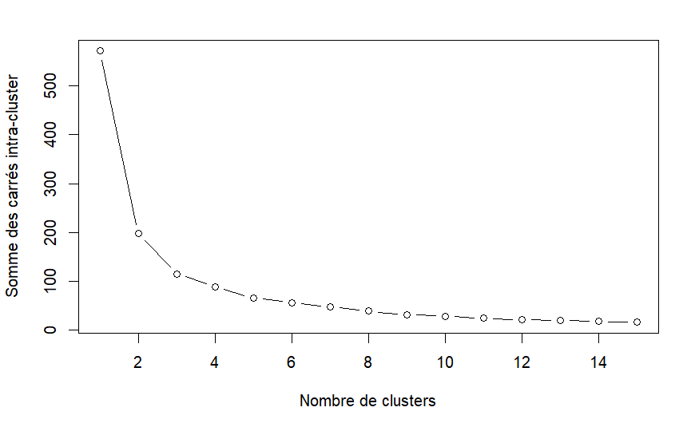

```r
# Initialize total within sum of squares error: wss
wss <- 0

# For 1 to 15 cluster centers
for (i in 1:15) {
  res.kdet <- kmeans(res.pcacr$ind$coord[,1:2], centers = i, nstart = 20)
  # Save total within sum of squares to wss variable
  wss[i] <- res.kdet$tot.withinss
}

# Plot total within sum of squares vs. number of clusters
plot(1:15, wss, type = "b",
     xlab = "Nombre de clusters",
     ylab = "Somme des carrés intra-cluster")
```

```r
#install.packages("NbClust")
```

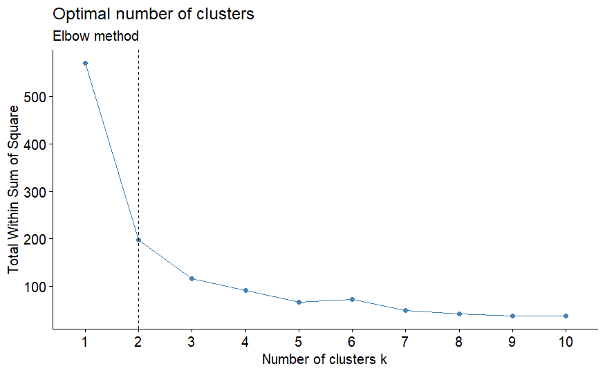

```r
#library(factoextra)

library(NbClust)
# Elbow method
fviz_nbclust(res.pcacr$ind$coord[,1:2], kmeans, method = "wss") +
    geom_vline(xintercept = 2, linetype = 2)+
  labs(subtitle = "Elbow method")
```

Dans cette figure, la ligne est positionnée manuellement. Elle pourrait être à deux ou à trois car deux “coudes” sont observés dans la courbe.

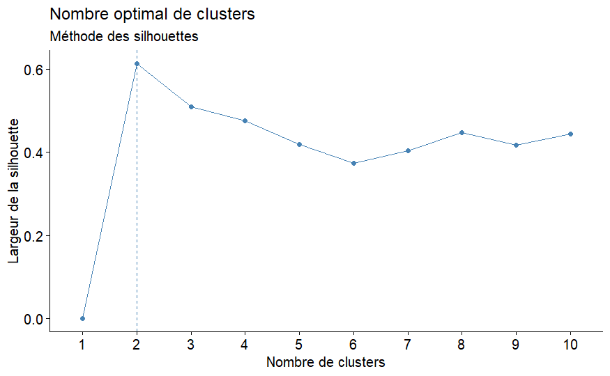

```r
# Silhouette method
fviz_nbclust(res.pcacr$ind$coord[,1:2], kmeans, method = "silhouette")+
labs(subtitle = "Méthode des silhouettes", title="Nombre optimal de clusters", x = "Nombre de clusters", y = "Largeur de la silhouette")
```

```
Clustering k = 1,2,..., K.max (= 10): .. done
Bootstrapping, b = 1,2,..., B (= 50)  [one "." per sample]:
.................................................. 50
```

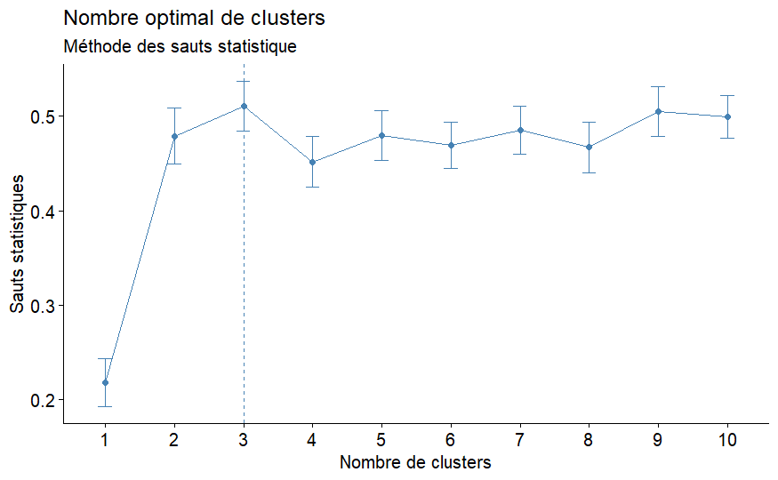

```r
# nboot = 50 to keep the function speedy.
# recommended value: nboot= 500 for your analysis.
# Use verbose = FALSE to hide computing progression.
set.seed(123)
fviz_nbclust(res.pcacr$ind$coord[,1:2], kmeans, nstart = 25, method = "gap_stat", nboot = 50)+
labs(subtitle = "Méthode des sauts statistique", title="Nombre optimal de clusters", x = "Nombre de clusters", y = "Sauts statistiques")
```

Les techniques consistent à déterminer le nombre de cluster à partir duquel la variance intra cluster décroît plus lentement. Ainsi constituer un nouveau cluster n’est pas différentiant. Dans notre cas le nombre de cluster pourrait être de deux ou de trois.